# **DEEP LEARNING PROJECT**

**Sergio Tambè** *and* **Chiara Santaera**

## **Introduction**

**Verbal communication** can be hindered in **noisy** environments or to address technical **limitations** in video recordings with **low-quality audio**, such as interpreting surveillance videos.

It can also find **applications** in:

- Protecting against audio **deepfakes** (through lip-reading)
- in **human-computer interaction**, allowing devices to be controlled without speaking.

Further developments could include integration into **augmented/virtual reality**, social **robotics**, and the creation of lifelike **avatars** capable of faithfully reproducing speech **movements**.

In this context, **Lip Reading** emerges as a vital tool. This project focuses on the analysis of videos *cropped* exclusively around the lips, excluding audio. This approach is *fundamental* in training a **neural network model** focused on *lip movements*.

## 1. **Exploratory Data Analysis (EDA)**

In this initial phase, we focus on the preliminary analysis of the dataset and the setup of the working environment. The primary goal is to transform raw video files into a structured format, allowing us to extract statistical insights and streamline the data feeding process for the neural network.

In the following cell, we import the needed libraries for this analysis.

```python
import os
import cv2
import pandas as pd
import numpy as np
import re
import matplotlib.pyplot as plt
import seaborn as sns
from sklearn.model_selection import train_test_split

import torch
from torch.utils.data import Dataset, DataLoader

from tqdm.notebook import tqdm
from sklearn.linear_model import LogisticRegression
from sklearn.metrics import accuracy_score, classification_report
from sklearn.preprocessing import LabelEncoder, StandardScaler
```

The **Data Exploration** begins by scanning the dataset directory. Since the dataset is organized into subfolders, we use os.walk to navigate and extract the file.

For every video, we collect the following attributes:

- **User**: Extracted from the subfolder name (the subject's identity).
- **word**: Extracted from the filename (the word being spoken), normalized to uppercase.
- **Frames**: The total temporal length of the video.
- **Resolution (res)**: The spatial dimensions (*Width x Height*).
- **FPS**: The fluidity of the recording (Frames Per Second).

This metadata is compiled into a **list** and subsequently converted into a **DataFrame**.

```python
dataset_path = "/kaggle/input/video-cropped/video_cropped"
data_list = []

for root, dirs, files in os.walk(dataset_path):
    for file_name in files:
        if file_name.lower().endswith('.mp4'):

            user = os.path.basename(root)

            name_without_ext = os.path.splitext(file_name)[0]
            word = name_without_ext.split('_')[-1].upper()

            video_path = os.path.join(root, file_name)
            cap = cv2.VideoCapture(video_path)

            frame_count = int(cap.get(cv2.CAP_PROP_FRAME_COUNT))
            fps = cap.get(cv2.CAP_PROP_FPS)
            width = int(cap.get(cv2.CAP_PROP_FRAME_WIDTH))
            height = int(cap.get(cv2.CAP_PROP_FRAME_HEIGHT))
            cap.release()

            data_list.append({
                'user': user,
                'file': file_name,
                'word': word,
                'frames': frame_count,
                'res': f"{width}x{height}",
                'fps': fps
            })

df = pd.DataFrame(data_list)

print(f"Video founded: {len(df)}")
print(df.head())
```

```
Video founded: 650
       user                           file   word  frames      res    fps
0  StefanoM    VID_20240426_172412_BED.mp4    BED      42  256x128  29.95
1  StefanoM  VID_20240426_172539_MOUSE.mp4  MOUSE      48  256x128  29.95
2  StefanoM  VID_20240426_172319_PIZZA.mp4  PIZZA      53  256x128  29.95
3  StefanoM    VID_20240426_172420_BED.mp4    BED      39  256x128  29.95
4  StefanoM  VID_20240426_172431_MONEY.mp4  MONEY      57  256x128  29.95
```

In the next part we perform a **visual analysis** focusing on two main aspects:

- **Word Distribution**: A bar plot to identify potential class imbalances among the words.
- **Frame Distribution**: Box plots to analyze the distribution of frame counts across different subjects and words, helping us justify the choice of our padding strategy.

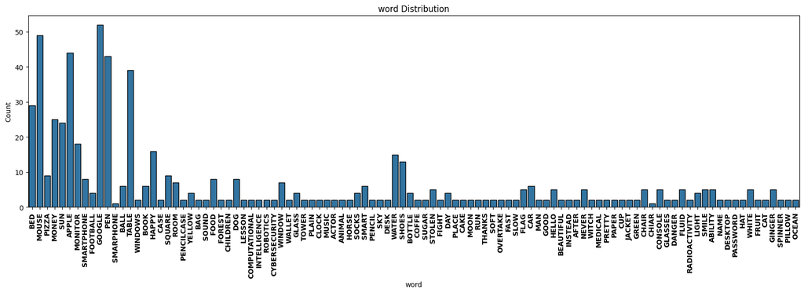

```python
# 1. Distribuzione delle classi
plt.figure(figsize=(20, 5))
sns.countplot(data=df, x='word', edgecolor='black')
plt.xticks(rotation=90, fontsize=10, fontweight='bold')
plt.title('word Distribution')
plt.xlabel('word')
plt.ylabel('Count')
plt.show()
```

```python
counts = df['word'].value_counts()
print(counts)
```

```
word
GOOGLE       52
MOUSE        49
APPLE        44
PEN          43
TABLE        39
             ..
HAT           2
OCEAN         2
SPINNER       2
SMARPHONE     1
CHIAR         1
Name: count, Length: 102, dtype: int64
```

The observation of the barplot reveals the need for further **data acquisition**, as the low frequency of words in the current dataset would limit training effectiveness.

Consequently, new videos were recorded with the collaboration of Professors **Fargetta** and **Ortis**. These videos were processed to extract the **lip area** exclusively and **normalized** to a 256x128 format.

Following the dataset expansion, the file **paths** were updated to include the new samples.

```python
dataset_path = "/kaggle/input/lip-reading/VIDEO_CROPPED+NUOVI"
data_list = []

for root, dirs, files in os.walk(dataset_path):
    for file_name in files:
        if file_name.lower().endswith('.mp4'):

            user = os.path.basename(root)

            name_without_ext = os.path.splitext(file_name)[0]
            word = name_without_ext.split('_')[-1].upper()
            word = re.sub(r'^\d+', '', word)

            video_path = os.path.join(root, file_name)
            cap = cv2.VideoCapture(video_path)

            frame_count = int(cap.get(cv2.CAP_PROP_FRAME_COUNT))
            fps = cap.get(cv2.CAP_PROP_FPS)
            width = int(cap.get(cv2.CAP_PROP_FRAME_WIDTH))
            height = int(cap.get(cv2.CAP_PROP_FRAME_HEIGHT))
            cap.release()

            data_list.append({
                'user': user,
                'file': file_name,
                'word': word,
                'frames': frame_count,
                'res': f"{width}x{height}",
                'fps': fps
            })

df = pd.DataFrame(data_list)

print(f"Video founded: {len(df)}")
print(df.head())
```

```
Video founded: 1439
       user                           file   word  frames      res    fps
0  StefanoM    VID_20240426_172412_BED.mp4    BED      42  256x128  29.95
1  StefanoM  VID_20240426_172539_MOUSE.mp4  MOUSE      48  256x128  29.95
2  StefanoM  VID_20240426_172319_PIZZA.mp4  PIZZA      53  256x128  29.95
3  StefanoM    VID_20240426_172420_BED.mp4    BED      39  256x128  29.95
4  StefanoM  VID_20240426_172431_MONEY.mp4  MONEY      57  256x128  29.95
```

As shown, the dataset has been **significantly expanded**; through the recording of new **videos**, the total count increased **from 650 to 1439** samples.

By looking at the barplot we can notice the presence of **"word noise"**. 'SMARPHONE', 'CHIAR', 'CLOCK2', 'BAWL' and some other words appear only few times.

We modify manually these words a correct way.

This step is crucial because it consolidates these samples into their correct categories, preventing the model from creating redundant and underpopulated classes.

```python
corrections = {
    'CHIAR': 'CHAIR',
    'SMARPHONE': 'SMARTPHONE',
    'COFFEE':'COFFE',
    'WHITCH':'WITCH',
    'WHICH':'WITCH',
    'CLOCK2':'CLOCK',
    'BOWL':'BALL',
    'PLAIN':'PLACE'
}
df['word'] = df['word'].replace(corrections)
```

Now we can generate the **final barplot**

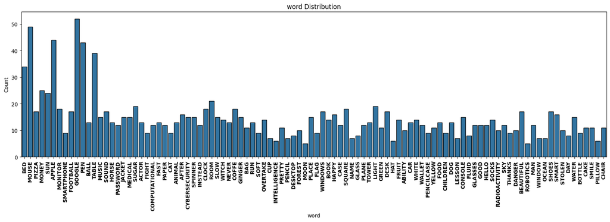

```python
# 1. Distribuzione delle classi
plt.figure(figsize=(20, 5))
sns.countplot(data=df, x='word', edgecolor='black')
plt.xticks(rotation=90, fontsize=10, fontweight='bold')
plt.title('word Distribution')
plt.xlabel('word')
plt.ylabel('Count')
plt.show()
```

```python
counts = df['word'].value_counts()
low_frequency_words = counts[counts < 10]
print(low_frequency_words)
print(low_frequency_words.count())
```

```
word
FIGHT           9
CAT             9
SMARTPHONE      9
FLAG            9
SOFT            9
PENCILCASE      9
CHILDREN        9
THANKS          9
BOTTLE          9
FLUID           8
DAY             8
DESKTOP         8
GLASS           8
CUP             7
PENCIL          7
NAME            7
OCEAN           7
WINDOW          7
LESSON          7
INTELLIGENCE    6
PILLOW          6
HAT             6
MOON            5
ROBOTICS        5
Name: count, dtype: int64
24
```

To **optimize** the training phase and ensure higher predictive **performance**, the dataset was refined by filtering out underrepresented classes.

Specifically, words with a frequency of **fewer than 10 samples** were **removed**. This approach aims to reduce statistical **noise** and allows the **neural network** to converge on a set of classes characterized by **sufficient** and balanced variance.

```python
df = df.groupby('word').filter(lambda x: len(x) >= 10)
print(f"Total number of Video: {len(df)}")
```

```
Total number of Video: 1256
```

Now we can analyze the **frame distribution** by generating the box plots.

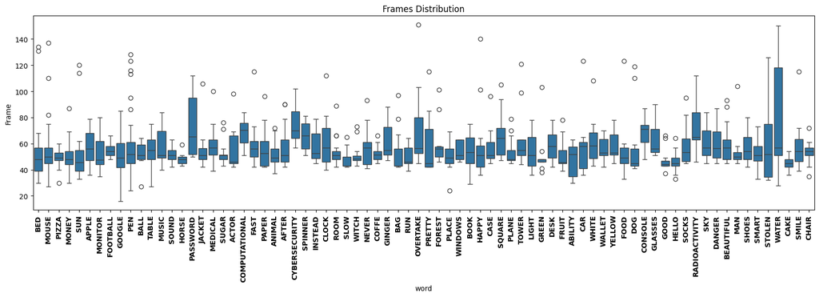

```
            frames          fps
count  1256.000000  1256.000000
mean     56.376592    30.398981
std      17.089800     4.009121
min      16.000000    24.350000
25%      46.000000    29.950000
50%      52.000000    30.000000
75%      63.000000    30.000000
max     151.000000    60.000000
```

```python
# 2. Distribuzione numero di frame
plt.figure(figsize=(20, 5))
sns.boxplot(data=df, x='word', y='frames')
plt.xticks(rotation=90, fontsize=10, fontweight='bold')
plt.title('Frames Distribution')
plt.xlabel('word')
plt.ylabel('Frame')
plt.show()

print(df.describe())
```

After analyzing the **Frames Distribution**, we observed that while the absolute maximum is 150 frames, most samples fall within 100 frames.

```python
max_frames = 90

videos_above = df[df['frames'] > max_frames]
num_above = len(videos_above)
percentage_above = (num_above / len(df)) * 100

print(f"Frames: {max_frames}")
print(f"Video missed (>{max_frames}): {percentage_above:.2f}%")
print(df.describe())
```

```
Frames: 90
Video missed (>90): 4.54%
            frames          fps
count  1256.000000  1256.000000
mean     56.376592    30.398981
std      17.089800     4.009121
min      16.000000    24.350000
25%      46.000000    29.950000
50%      52.000000    30.000000
75%      63.000000    30.000000
max     151.000000    60.000000
```

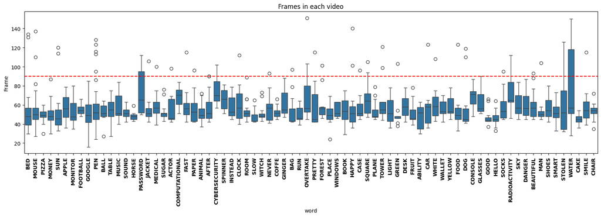

```python
df['frames_padded'] = max_frames

plt.figure(figsize=(20, 5))

sns.boxplot(data=df, x='word', y='frames')
plt.xticks(rotation=90, fontsize=10, fontweight='bold')
plt.axhline(y=max_frames, color='red', linestyle='--', label=f'Target Padding ({max_frames})')
plt.title('Frames in each video')
plt.xlabel('word')
plt.ylabel('Frame')

plt.show()
```

## **Data Splitting Strategy**

To simulate a real-world scenario where the system must interact with previously **unseen users**, we structured the data split to ensure there is no subject overlap between the **training** and **testing** phases.

Specifically, we reserved videos featuring users **Sergio and Giuseppe** (representing approximately **20%** of the total dataset) for the **Validation** and **Test** sets, while assigning the remaining **80%** of users to the **Training** set. This strategic choice allows us to evaluate the model on '**unknown**' subjects while maintaining domain consistency, as the **vocabulary** found in the test set is fully represented within the training data. This approach ensures that the performance metrics **accurately** reflect the model's actual **lip-reading** capability, rather than its ability to memorize specific **facial** features.

In this way we divide the dataset into 80% - 10% - 10%

```python
specific_users = ['SERGIO', 'GIUSEPPE']
mask_val_test = df['user'].str.upper().isin(specific_users)

df_train = df[~mask_val_test].copy()

df_val_test = df[mask_val_test].copy()

df_val, df_test = train_test_split(df_val_test, test_size=0.5, random_state=42, shuffle=True)

print(f"-----------------------")
print(f'Total video filmed by SERGIO and GIUSEPPE = {mask_val_test.sum()}')
print(f"Training Set:   {len(df_train)} video")
print(f"Validation Set: {len(df_val)} video")
print(f"Test Set:       {len(df_test)} video")
print(f"-----------------------")

assert len(set(df_train.index).intersection(set(df_val.index))) == 0
assert len(set(df_val.index).intersection(set(df_test.index))) == 0
```

```
-----------------------
Total video filmed by SERGIO and GIUSEPPE = 258
Training Set:   998 video
Validation Set: 129 video
Test Set:       129 video
-----------------------
```

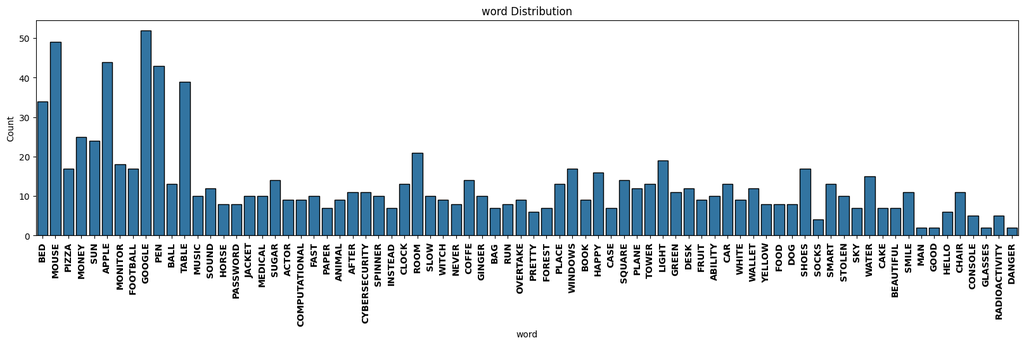

```python
# 1. Distribuzione delle classi
plt.figure(figsize=(20, 15))
plt.subplot(3,1,1)
sns.countplot(data=df_train, x='word', edgecolor='black')
plt.xticks(rotation=90, fontsize=10, fontweight='bold')
plt.title('word Distribution')
plt.xlabel('word')
plt.ylabel('Count')

plt.show()
```

An analysis of the **training** set's class distribution revealed that any words appeared fewer than **5 times**. To ensure efficient learning and prevent the model from overfitting on underrepresented classes, we established a minimum frequency threshold of 5 occurrences. Consequently, these rare words were **removed** not only from the training set but also from the **validation** and **test sets**. This filtering process guarantees vocabulary consistency across the splits: every word evaluated in the validation and test phases is present in the training phase, ensuring the model is tested on **known classes** pronounced by unseen users.

```python
# parole da rimuovere (< 5 nel Training)
train_counts = df_train['word'].value_counts()
words_to_remove = train_counts[train_counts < 5].index.tolist()

len_train_old = len(df_train)
len_val_old = len(df_val)
len_test_old = len(df_test)

df_train = df_train[~df_train['word'].isin(words_to_remove)].copy()
df_val = df_val[~df_val['word'].isin(words_to_remove)].copy()
df_test = df_test[~df_test['word'].isin(words_to_remove)].copy()

print("-" * 40)
print(f"Training Set:   rimossi {len_train_old - len(df_train)} video. (Nuovo totale: {len(df_train)})")
print(f"Validation Set: rimossi {len_val_old - len(df_val)} video. (Nuovo totale: {len(df_val)})")
print(f"Test Set:       rimossi {len_test_old - len(df_test)} video. (Nuovo totale: {len(df_test)})")
print("-" * 40)
```

```
----------------------------------------
Training Set:   rimossi 12 video. (Nuovo totale: 986)
Validation Set: rimossi 19 video. (Nuovo totale: 110)
Test Set:       rimossi 29 video. (Nuovo totale: 100)
----------------------------------------
```

## **Modeling Strategy & Baselines**

## 3. Baseline Model: Logistic Regression

### 3.1. Rationale and Methodology

Before implementing complex Deep Learning architectures, establishing a **baseline** is essential to quantify the complexity of the task and validate the need for advanced models. The primary objective of this experiment is to test the hypothesis that purely spatial information (the shape of the mouth), without the temporal component (movement), is insufficient for speech recognition.

For this baseline, we adopted a **static feature extraction** approach:

1. **Temporal Collapse:** Each video sample, consisting of $T$ frames with dimensions $H \times W$, is reduced to a single static image by calculating the **pixel-wise mean** across the temporal axis (Global Temporal Average).
2. **Flattening:** The resulting image, which represents the "average shape" of the mouth during the utterance, is flattened into a 1D vector.
3. **Classification:** This vector serves as the input for a multinomial **Logistic Regression** classifier.

This approach deliberately eliminates the sequential order of frames, effectively testing whether the "average" lip aperture is discriminative enough to distinguish between different words.

```python
import cv2
import numpy as np
import os
import pandas as pd
from tqdm.notebook import tqdm
from sklearn.linear_model import LogisticRegression
from sklearn.metrics import accuracy_score, classification_report
from sklearn.preprocessing import LabelEncoder, StandardScaler

sample_file = df_train.iloc[0]['file']
sample_user = df_train.iloc[0]['user']
found_root = None

for root, dirs, files in os.walk('/kaggle/input/lip-reading/VIDEO_CROPPED+NUOVI'):
    if sample_file in files:

        if root.endswith(sample_user):
            found_root = os.path.dirname(root)
            print(f"  Trovato file '{sample_file}' in: {root}")
            print(f"  La radice corretta del dataset è: {found_root}")
            break

if found_root is None:
    raise FileNotFoundError(f"  ERRORE GRAVE: Non riesco a trovare il file '{sample_file}' da nessuna parte in /kaggle/input.")

dataset_path = found_root
TARGET_SIZE = (64, 32)

def extract_features_from_df(df, base_path):
    X = []
    y = []

    print(f"  Elaborazione di {len(df)} video...")

    error_count = 0

    for row in tqdm(df.itertuples(), total=len(df)):
        full_path = os.path.join(base_path, row.user, row.file)

        cap = cv2.VideoCapture(full_path)
        frames = []

        while True:
            ret, frame = cap.read()
            if not ret: break
            frame = cv2.resize(frame, TARGET_SIZE)
            frames.append(frame)
        cap.release()

        if len(frames) > 0:
            mean_frame = np.mean(frames, axis=0).astype(np.uint8)
            X.append(mean_frame.flatten())
            y.append(row.word)
        else:
            error_count += 1

    if len(X) == 0:
        raise ValueError("  TUTTI i video hanno fallito il caricamento. Controlla il percorso stampato sopra!")

    print(f"  Caricati correttamente {len(X)} su {len(df)} video.")
    return np.array(X), np.array(y)

print("\n--- Estrazione Training Set ---")
X_train, y_train = extract_features_from_df(df_train, dataset_path)

print("\n--- Estrazione Test Set ---")
X_test, y_test = extract_features_from_df(df_test, dataset_path)

print("\n  Preparazione Dati...")

le = LabelEncoder()
y_train_enc = le.fit_transform(y_train)

# Gestione Test Set sicuro
y_test_enc = []
valid_indices = []
for i, word in enumerate(y_test):
    if word in le.classes_:
        y_test_enc.append(le.transform([word])[0])
        valid_indices.append(i)

X_test = X_test[valid_indices]
y_test_enc = np.array(y_test_enc)

scaler = StandardScaler()
X_train_scaled = scaler.fit_transform(X_train)
X_test_scaled = scaler.transform(X_test)

print("  Addestramento Regressione Logistica...")
log_reg = LogisticRegression(max_iter=1000, n_jobs=-1, multi_class='multinomial')
log_reg.fit(X_train_scaled, y_train_enc)

# --- 5. RISULTATI ---
y_pred = log_reg.predict(X_test_scaled)
accuracy = accuracy_score(y_test_enc, y_pred)

print(f"\n  ACCURACY BASELINE: {accuracy:.4f} ({accuracy*100:.2f}%)")
print(classification_report(y_test_enc, y_pred, target_names=le.classes_, labels=range(min(10, len(le.classes_)))))
```

```
🔍 Diagnostica percorsi in corso...
✅ Trovato file 'VID_20240426_172412_BED.mp4' in: /kaggle/input/lip-reading/VIDEO_CROPPED+NUOVI/StefanoM
📂 La radice corretta del dataset è: /kaggle/input/lip-reading/VIDEO_CROPPED+NUOVI

--- Estrazione Training Set ---
⚙️ Elaborazione di 986 video...
```

```
✅ Caricati correttamente 986 su 986 video.

--- Estrazione Test Set ---
⚙️ Elaborazione di 100 video...
```

```
✅ Caricati correttamente 100 su 100 video.

🧠 Preparazione Dati...
🧠 Addestramento Regressione Logistica...
```

```
🏆 ACCURACY BASELINE: 0.0200 (2.00%)
               precision    recall  f1-score   support

      ABILITY       0.00      0.00      0.00         0
        ACTOR       0.00      0.00      0.00         4
        AFTER       0.00      0.00      0.00         1
       ANIMAL       0.00      0.00      0.00         2
        APPLE       0.00      0.00      0.00         0
          BAG       0.00      0.00      0.00         1
         BALL       0.00      0.00      0.00         0
    BEAUTIFUL       0.00      0.00      0.00         6
          BED       0.00      0.00      0.00         0
         BOOK       0.00      0.00      0.00         1

    micro avg       0.00      0.00      0.00        15
    macro avg       0.00      0.00      0.00        15
 weighted avg       0.00      0.00      0.00        15
```

### 3.2. Results Analysis

The quantitative results unequivocally confirm the limitations of a static approach. The model achieved an accuracy of **2.00%** on the Test Set.

$$P(\text{random}) = \frac{1}{71} \approx 1.4\%$$

The fact that Logistic Regression exceeds random chance by only **0.6%** indicates that the model failed to learn any significant discriminative features. As evidenced by the *Classification Report*, the model fails to predict the vast majority of classes (yielding Precision and Recall scores of 0), likely collapsing its predictions onto a few majority classes or acting almost blindly.

### 3.3. Conclusion

The failure of this experiment (2.00% accuracy) serves as a crucial scientific validation for the subsequent phases of this project:

1. **Insufficiency of Static Features:** The "average" of lip movements is mathematically similar for phonetically distinct words (e.g., words starting with a closed mouth and ending open will produce a similar mean image, regardless of the intermediate movements).
2. **Nature of the Problem:** This result demonstrates that Lip Reading is not an **Object Recognition** task (identifying a static shape) but an **Action Recognition** task (interpreting motion).

Consequently, to achieve acceptable performance, it is imperative to transition to architectures capable of modeling temporal dependencies and frame-to-frame transitions, such as **2D CNNs** with temporal pooling or **3D CNNs**.

```python
import numpy as np
import cv2
import os
from tqdm.notebook import tqdm

# --- CONFIGURAZIONE ---
MAX_FRAMES = 90
TARGET_SIZE = (64, 32)

def load_data_with_masking(df, base_path):
    """
    Carica i video, applica Zero Padding fino a MAX_FRAMES,
    crea le maschere ed ESCLUDE i video che superano MAX_FRAMES.
    """
    X_data = []      # Tensore video (N, 90, 32, 64, 3)
    y_data = []      # Etichette
    masks = []       # Maschere booleane (N, 90)

    kept = 0
    skipped = 0

    for row in tqdm(df.itertuples(), total=len(df)):
        full_path = os.path.join(base_path, row.user, row.file)

        cap = cv2.VideoCapture(full_path)
        frames = []
        while True:
            ret, frame = cap.read()
            if not ret: break
            frame = cv2.resize(frame, TARGET_SIZE)
            frames.append(frame)
        cap.release()

        L = len(frames)

        # Se è troppo lungo, lo scartiamo
        if L > MAX_FRAMES:
            skipped += 1
            continue

        if L == 0:
            skipped += 1
            continue

        padded_video = np.zeros((MAX_FRAMES, TARGET_SIZE[1], TARGET_SIZE[0], 3), dtype=np.uint8)

        mask = np.zeros((MAX_FRAMES,), dtype=np.float32)
        padded_video[:L] = np.array(frames)

        mask[:L] = 1.0

        X_data.append(padded_video)
        masks.append(mask)
        y_data.append(row.word)
        kept += 1

    print(f"\n✅ Completato!")
    print(f"📹 Video mantenuti: {kept}")
    print(f"🗑️ Video scartati (> {MAX_FRAMES} frames o errori): {skipped}")

    return np.array(X_data), np.array(y_data), np.array(masks)

print("--- Caricamento Training Set ---")
X_train, y_train_raw, mask_train = load_data_with_masking(df_train, dataset_path)

print("\n--- Caricamento Test Set ---")
X_test, y_test_raw, mask_test = load_data_with_masking(df_test, dataset_path)

print("\n🛁 Normalizzazione pixel...")
X_train = X_train.astype('float32') / 255.0
X_test = X_test.astype('float32') / 255.0

from sklearn.preprocessing import LabelEncoder
from keras.utils import to_categorical # Se usiamo Keras/Tensorflow

le = LabelEncoder()
y_train_enc = le.fit_transform(y_train_raw)
# Gestione label sicura
y_test_enc = []
valid_idx = []
for i, w in enumerate(y_test_raw):
    if w in le.classes_:
        y_test_enc.append(le.transform([w])[0])
        valid_idx.append(i)

X_test = X_test[valid_idx]
mask_test = mask_test[valid_idx]
y_test_enc = np.array(y_test_enc)

num_classes = len(le.classes_)
y_train_cat = to_categorical(y_train_enc, num_classes)
y_test_cat = to_categorical(y_test_enc, num_classes)

print(f"\n📦 Shape finali:")
print(f"X_train: {X_train.shape} (Video)")
print(f"Mask_train: {mask_train.shape} (Maschere)")
print(f"y_train: {y_train_cat.shape} (Label)")
```

```
--- Caricamento Training Set ---
🔄 Elaborazione 986 video con Padding & Masking...
```

```
✅ Completato!
📹 Video mantenuti: 939
🗑️ Video scartati (> 90 frames o errori): 47

--- Caricamento Test Set ---
🔄 Elaborazione 100 video con Padding & Masking...
```

```
✅ Completato!
📹 Video mantenuti: 96
🗑️ Video scartati (> 90 frames o errori): 4

🛁 Normalizzazione pixel...

📦 Shape finali:
X_train: (939, 90, 32, 64, 3) (Video)
Mask_train: (939, 90) (Maschere)
y_train: (939, 71) (Label)
```

## 4. Proposed Method: Frame-by-Frame 2D CNN with Temporal Pooling

### 4.1. Architecture Design

To overcome the limitations of the static baseline (which achieved only 2.00% accuracy), we implemented a **Time-Distributed 2D CNN**. This architecture treats the video not as a single 3D volume, but as a sequence of independent images, applying the same visual feature extractor to each frame individually.

The pipeline consists of the following stages:

1. **Input Handling:** Video samples are padded to a fixed length of $T=90$ frames. A binary **masking** mechanism is introduced to ensure that padding frames (zeros) do not influence the learning process.
2. **Visual Feature Extraction (VGG-style):** We employ a lightweight VGG-like block consisting of three convolutional layers (32, 64, 128 filters) followed by Batch Normalization and Max Pooling. The crucial component is the `TimeDistributed` wrapper, which shares the weights across all 90 time steps. This allows the network to learn a consistent representation of mouth shapes (e.g., "lips rounded", "lips closed") regardless of exactly *when* they occur in the video.
3. **Temporal Aggregation (Global Max Pooling):** Instead of using Recurrent Neural Networks (RNNs) at this stage, we applied **Global Temporal Max Pooling**.
   - *Operation:* $y = \max_{t=1}^{T} (x_t)$
   - *Intuition:* This operation detects *if* a specific visual feature (e.g., the mouth shape for the letter 'O') occurred *at any point* in the sequence, discarding the temporal order but capturing the presence of salient articulatory events.
4. **Classification:** The aggregated feature vector is passed through a dense layer (256 units) with Dropout (0.5) to predict the word class.

### 4.2. Implementation and Training Setup

The model is implemented using TensorFlow/Keras. Given the high dimensionality of the input data (processing 90 frames per video for every sample), efficient resource management is critical to avoid memory saturation.

To accelerate the training phase, we utilize a **Multi-GPU strategy** (`tf.distribute.MirroredStrategy`), which distributes the computational load across two NVIDIA Tesla T4 GPUs.

The training configuration includes:

- **Optimizer:** Adam with an initial learning rate of $0.001$.
- **Loss Function:** Categorical Cross-Entropy (for multi-class classification).
- **Callbacks:**
  - **EarlyStopping**: Monitors validation loss to stop training if no improvement is seen for 10 epochs, preventing overfitting.
  - **ReduceLROnPlateau**: Reduces the learning rate by a factor of 0.5 if the validation loss stagnates, allowing for fine-tuning.
- **Batch Size:** Set to **8** (per replica strategy) to prevent Out-Of-Memory (OOM) errors given the large memory footprint of the temporal sequences.

```
INFO:tensorflow:Using MirroredStrategy with devices ('/job:localhost/replica:0/task:0/device:GPU:0', '/job:localhost/replica:0/task:0/device:GPU:1')
```

[output not shown]

```
✅ Numero di GPU in uso: 2
🏗️ Costruzione modello su GPU...
```

```
Model: "functional"
```

```
┏━━━━━━━━━━━━━━━━━━━━━┳━━━━━━━━━━━━━━━━━━━┳━━━━━━━━━━━━┳━━━━━━━━━━━━━━━━━━━┓
┃ Layer (type)        ┃ Output Shape      ┃    Param # ┃ Connected to      ┃
┡━━━━━━━━━━━━━━━━━━━━━╇━━━━━━━━━━━━━━━━━━━╇━━━━━━━━━━━━╇━━━━━━━━━━━━━━━━━━━┩
│ video_input         │ (None, 90, 32,    │          0 │ -                 │
│ (InputLayer)        │ 64, 3)            │            │                   │
├─────────────────────┼───────────────────┼────────────┼───────────────────┤
│ time_distributed    │ (None, 90, 32,    │        896 │ video_input[0][0] │
│ (TimeDistributed)   │ 64, 32)           │            │                   │
├─────────────────────┼───────────────────┼────────────┼───────────────────┤
│ time_distributed_1  │ (None, 90, 16,    │          0 │ time_distributed… │
│ (TimeDistributed)   │ 32, 32)           │            │                   │
├─────────────────────┼───────────────────┼────────────┼───────────────────┤
│ time_distributed_2  │ (None, 90, 16,    │        128 │ time_distributed… │
│ (TimeDistributed)   │ 32, 32)           │            │                   │
├─────────────────────┼───────────────────┼────────────┼───────────────────┤
│ time_distributed_3  │ (None, 90, 16,    │     18,496 │ time_distributed… │
│ (TimeDistributed)   │ 32, 64)           │            │                   │
├─────────────────────┼───────────────────┼────────────┼───────────────────┤
│ time_distributed_4  │ (None, 90, 8, 16, │          0 │ time_distributed… │
│ (TimeDistributed)   │ 64)               │            │                   │
├─────────────────────┼───────────────────┼────────────┼───────────────────┤
│ time_distributed_5  │ (None, 90, 8, 16, │        256 │ time_distributed… │
│ (TimeDistributed)   │ 64)               │            │                   │
├─────────────────────┼───────────────────┼────────────┼───────────────────┤
│ time_distributed_6  │ (None, 90, 8, 16, │     73,856 │ time_distributed… │
│ (TimeDistributed)   │ 128)              │            │                   │
├─────────────────────┼───────────────────┼────────────┼───────────────────┤
│ time_distributed_7  │ (None, 90, 4, 8,  │          0 │ time_distributed… │
│ (TimeDistributed)   │ 128)              │            │                   │
├─────────────────────┼───────────────────┼────────────┼───────────────────┤
│ time_distributed_8  │ (None, 90, 4, 8,  │        512 │ time_distributed… │
│ (TimeDistributed)   │ 128)              │            │                   │
├─────────────────────┼───────────────────┼────────────┼───────────────────┤
│ mask_input          │ (None, 90)        │          0 │ -                 │
│ (InputLayer)        │                   │            │                   │
├─────────────────────┼───────────────────┼────────────┼───────────────────┤
│ time_distributed_9  │ (None, 90, 4096)  │          0 │ time_distributed… │
│ (TimeDistributed)   │                   │            │                   │
├─────────────────────┼───────────────────┼────────────┼───────────────────┤
│ reshape (Reshape)   │ (None, 90, 1)     │          0 │ mask_input[0][0]  │
├─────────────────────┼───────────────────┼────────────┼───────────────────┤
│ multiply (Multiply) │ (None, 90, 4096)  │          0 │ time_distributed… │
│                     │                   │            │ reshape[0][0]     │
├─────────────────────┼───────────────────┼────────────┼───────────────────┤
│ global_max_pooling… │ (None, 4096)      │          0 │ multiply[0][0]    │
│ (GlobalMaxPooling1… │                   │            │                   │
├─────────────────────┼───────────────────┼────────────┼───────────────────┤
│ dense (Dense)       │ (None, 256)       │  1,048,832 │ global_max_pooli… │
├─────────────────────┼───────────────────┼────────────┼───────────────────┤
│ dropout (Dropout)   │ (None, 256)       │          0 │ dense[0][0]       │
├─────────────────────┼───────────────────┼────────────┼───────────────────┤
│ dense_1 (Dense)     │ (None, 71)        │     18,247 │ dropout[0][0]     │
└─────────────────────┴───────────────────┴────────────┴───────────────────┘
```

```
 Total params: 1,161,223 (4.43 MB)
```

```
 Trainable params: 1,160,775 (4.43 MB)
```

```
 Non-trainable params: 448 (1.75 KB)
```

[output not shown]

```
I0000 00:00:1769509518.546414   17189 cuda_dnn.cc:529] Loaded cuDNN version 91002
I0000 00:00:1769509518.545838   17190 cuda_dnn.cc:529] Loaded cuDNN version 91002
```

```
118/118 ━━━━━━━━━━━━━━━━━━━━ 0s 399ms/step - accuracy: 0.0184 - loss: 6.6613INFO:tensorflow:Reduce to /job:localhost/replica:0/task:0/device:CPU:0 then broadcast to ('/job:localhost/replica:0/task:0/device:CPU:0',).
118/118 ━━━━━━━━━━━━━━━━━━━━ 161s 579ms/step - accuracy: 0.0185 - loss: 6.6479 - val_accuracy: 0.0000e+00 - val_loss: 4.2724 - learning_rate: 0.0010
118/118 ━━━━━━━━━━━━━━━━━━━━ 48s 409ms/step - accuracy: 0.0576 - loss: 4.2566 - val_accuracy: 0.0000e+00 - val_loss: 4.2838 - learning_rate: 0.0010
118/118 ━━━━━━━━━━━━━━━━━━━━ 48s 408ms/step - accuracy: 0.0545 - loss: 4.2322 - val_accuracy: 0.0000e+00 - val_loss: 6.7671 - learning_rate: 0.0010
118/118 ━━━━━━━━━━━━━━━━━━━━ 48s 409ms/step - accuracy: 0.0501 - loss: 4.2734 - val_accuracy: 0.0000e+00 - val_loss: 4.3080 - learning_rate: 0.0010
118/118 ━━━━━━━━━━━━━━━━━━━━ 0s 400ms/step - accuracy: 0.0642 - loss: 4.2083
Epoch 5: ReduceLROnPlateau reducing learning rate to 0.0005000000237487257.
118/118 ━━━━━━━━━━━━━━━━━━━━ 48s 408ms/step - accuracy: 0.0641 - loss: 4.2083 - val_accuracy: 0.0000e+00 - val_loss: 4.3191 - learning_rate: 0.0010
118/118 ━━━━━━━━━━━━━━━━━━━━ 48s 408ms/step - accuracy: 0.0535 - loss: 4.1986 - val_accuracy: 0.0000e+00 - val_loss: 4.3249 - learning_rate: 5.0000e-04
118/118 ━━━━━━━━━━━━━━━━━━━━ 48s 409ms/step - accuracy: 0.0581 - loss: 4.1916 - val_accuracy: 0.0000e+00 - val_loss: 4.3307 - learning_rate: 5.0000e-04
118/118 ━━━━━━━━━━━━━━━━━━━━ 49s 409ms/step - accuracy: 0.0559 - loss: 4.1849 - val_accuracy: 0.0000e+00 - val_loss: 4.3365 - learning_rate: 5.0000e-04
118/118 ━━━━━━━━━━━━━━━━━━━━ 0s 399ms/step - accuracy: 0.0529 - loss: 4.1909
Epoch 9: ReduceLROnPlateau reducing learning rate to 0.0002500000118743628.
118/118 ━━━━━━━━━━━━━━━━━━━━ 48s 408ms/step - accuracy: 0.0529 - loss: 4.1908 - val_accuracy: 0.0000e+00 - val_loss: 4.3422 - learning_rate: 5.0000e-04
118/118 ━━━━━━━━━━━━━━━━━━━━ 48s 408ms/step - accuracy: 0.0505 - loss: 4.1766 - val_accuracy: 0.0000e+00 - val_loss: 4.3449 - learning_rate: 2.5000e-04
118/118 ━━━━━━━━━━━━━━━━━━━━ 48s 408ms/step - accuracy: 0.0658 - loss: 4.1776 - val_accuracy: 0.0000e+00 - val_loss: 4.3480 - learning_rate: 2.5000e-04
Epoch 11: early stopping
Restoring model weights from the end of the best epoch: 1.
```

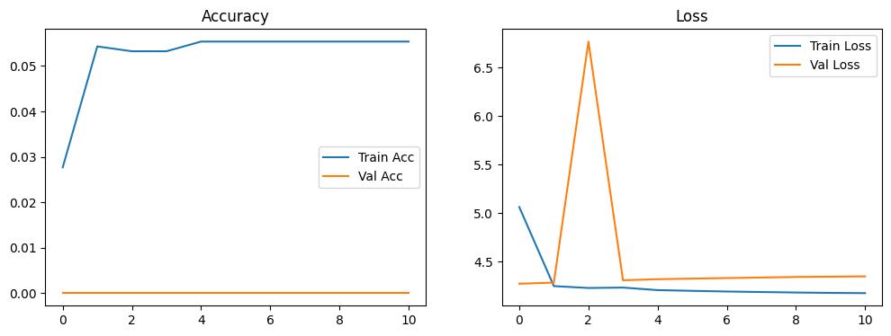

```
3/3 ━━━━━━━━━━━━━━━━━━━━ 21s 145ms/step - accuracy: 0.0000e+00 - loss: 4.2722

🏆 TEST ACCURACY (CNN 2D): 0.00%
```

```python
import tensorflow as tf
from tensorflow.keras import layers, models, Input
from tensorflow.keras.callbacks import EarlyStopping, ReduceLROnPlateau
import matplotlib.pyplot as plt

INPUT_SHAPE = (90, 32, 64, 3)
NUM_CLASSES = y_train_cat.shape[1]

BATCH_SIZE = 8

def build_2d_cnn_model():
    video_input = Input(shape=INPUT_SHAPE, name='video_input')
    mask_input = Input(shape=(90,), name='mask_input')

    # --- VGG semplice ---
    x = layers.TimeDistributed(layers.Conv2D(32, (3, 3), padding='same', activation='relu'))(video_input)
    x = layers.TimeDistributed(layers.MaxPooling2D((2, 2)))(x)
    x = layers.TimeDistributed(layers.BatchNormalization())(x)

    x = layers.TimeDistributed(layers.Conv2D(64, (3, 3), padding='same', activation='relu'))(x)
    x = layers.TimeDistributed(layers.MaxPooling2D((2, 2)))(x)
    x = layers.TimeDistributed(layers.BatchNormalization())(x)

    x = layers.TimeDistributed(layers.Conv2D(128, (3, 3), padding='same', activation='relu'))(x)
    x = layers.TimeDistributed(layers.MaxPooling2D((2, 2)))(x)
    x = layers.TimeDistributed(layers.BatchNormalization())(x)

    x = layers.TimeDistributed(layers.Flatten())(x)

    # --- mask ---
    mask_expanded = layers.Reshape((90, 1))(mask_input)
    x = layers.Multiply()([x, mask_expanded])

    # --- max pooling ---
    x = layers.GlobalMaxPooling1D()(x)

    # --- CLASSIFICATORE ---
    x = layers.Dense(256, activation='relu')(x)
    x = layers.Dropout(0.5)(x)
    output = layers.Dense(NUM_CLASSES, activation='softmax')(x)

    model = models.Model(inputs=[video_input, mask_input], outputs=output)
    return model

strategy = tf.distribute.MirroredStrategy()
print(f"  Numero di GPU in uso: {strategy.num_replicas_in_sync}")

with strategy.scope():
    print("  Costruzione modello su GPU...")
    model = build_2d_cnn_model()
    model.compile(optimizer=tf.keras.optimizers.Adam(learning_rate=0.001),
                  loss='categorical_crossentropy',
                  metrics=['accuracy'])

model.summary()

# --- 2. ADDESTRAMENTO ---
print("\n  Inizio Addestramento CNN 2D su Multi-GPU...")

early_stop = EarlyStopping(monitor='val_loss', patience=10, restore_best_weights=True, verbose=1)
reduce_lr = ReduceLROnPlateau(monitor='val_loss', factor=0.5, patience=4, verbose=1)

history = model.fit(
    x=[X_train, mask_train],
    y=y_train_cat,
    validation_data=([X_test, mask_test], y_test_cat),
    epochs=50,
    batch_size=BATCH_SIZE, # Usiamo 32 qui
    callbacks=[early_stop, reduce_lr],
    verbose=1
)

# --- 3. GRAFICI RISULTATI ---
plt.figure(figsize=(12, 4))
plt.subplot(1, 2, 1)
plt.plot(history.history['accuracy'], label='Train Acc')
plt.plot(history.history['val_accuracy'], label='Val Acc')
plt.title('Accuracy')
plt.legend()

plt.subplot(1, 2, 2)
plt.plot(history.history['loss'], label='Train Loss')
plt.plot(history.history['val_loss'], label='Val Loss')
plt.title('Loss')
plt.legend()
plt.show()

# Stampa risultato finale
loss, acc = model.evaluate([X_test, mask_test], y_test_cat)
print(f"\n🏆 TEST ACCURACY (CNN 2D): {acc*100:.2f}%")
```

### 4.3. Results and Analysis

The 2D CNN model was trained for 11 epochs before Early Stopping was triggered due to the lack of improvement in validation loss.

1. **Subject Domain Shift:** The model likely overfitted to the specific somatic features of the training subjects (e.g., identity, lighting conditions, specific facial traits) rather than learning the universal motion of the lips. When presented with unseen subjects in the Test Set (Sergio, Giuseppe), the learned features were not applicable.
2. **Loss of Temporal Dynamics:** The **Global Max Pooling** operation effectively destroys the temporal order of the sequence. By flattening the time dimension into a single "presence/absence" map, the network cannot distinguish between words that share similar phonemes but in a different order (e.g., distinguishing "ALTO" from "LATO").

**Conclusion:** This experiment confirms that treating the video as a "bag of frames" without explicit sequence modeling is insufficient for subject-independent lip reading. To achieve generalization and distinguish complex words, the model must explicitly learn the **temporal evolution** of the visual features. This finding motivates the transition to spatiotemporal architectures, such as the Hybrid CNN-LSTM, which will be explored in the next experiment.